# LSTM STOCK PREDICTOR

```python
import yfinance as yf
import numpy as np
import matplotlib.pyplot as plt
import pandas as pd
from sklearn.preprocessing import MinMaxScaler
%matplotlib inline
```

```python
start_date="2010-01-01"
end_date="2018-12-31"
stock_data=pd.DataFrame()

# download LNT stock price data
stock_data = yf.download("RELIANCE.NS", start=start_date, end=end_date)
stock_data.to_csv('rel_stock_data.csv', index=False)
```

```
[*********************100%***********************]  1 of 1 completed
```

```python
stock_data = pd.read_csv("rel_stock_data.csv")[["Close"]]
stock_data.describe()
```

|  | Close |
| --- | --- |
| count | 2218.000000 |
| mean | 549.785863 |
| std | 204.448817 |
| min | 334.875702 |
| 25% | 424.649750 |
| 50% | 485.064575 |
| 75% | 533.016296 |
| max | 1306.614624 |

```python
# Divide into 90% training and 10% testing
X_tr = stock_data[:int(len(stock_data)*0.9)].values
X_te = stock_data[int(len(stock_data)*0.9):].values

#len(train_df), len(test_df)
```

```python
#train_df
```

```python
#train_df.columns
```

```python
#tr_df=train_df[::-1]
```

```python
#te_df=test_df[::-1]
```

```python
#te_df.shape
```

```python
#X_tr=train_df['PREV. CLOSE ']
#X_te=test_df['PREV. CLOSE ']
```

```python
#X_tr.shape
```

```python
#X_tr=X_tr.dropna()
#X_te=X_te.dropna()
```

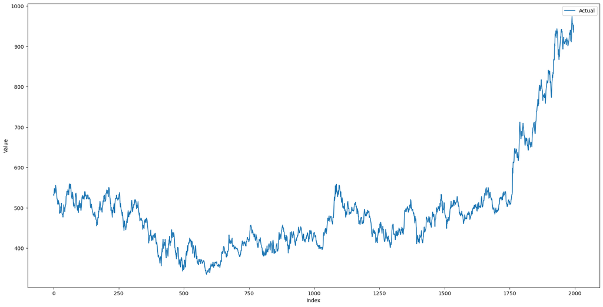

```python
plt.figure(figsize=(20, 10))
plt.plot(X_tr, label='Actual')
#plt.plot(y_p, label='Predicted')
plt.xlabel('Index')
plt.ylabel('Value')
#plt.title('Actual vs Predicted (Matplotlib)')
plt.legend()
plt.show()
```

```python
scale=MinMaxScaler(feature_range=(0,1))
Xr1_df=scale.fit_transform(np.array(X_tr).reshape(-1,1))
```

```python
Xe1_df=scale.fit_transform(np.array(X_te).reshape(-1,1))
```

Now, I'll be keeping timestamp=10, i.e every 10 day inputs determine the 11th day output. For that we need to perform data preprocessing

```python
def create_sequences(data, timestep):
    X, y = [], []
    for i in range(len(data) - timestep):
        X.append(data[i:(i+timestep)])  # Input sequence of length timestep
        y.append(data[i+timestep])    # Output value for the next day
    return np.array(X), np.array(y)
```

```python
Xr1_df.shape
```

```
(1996, 1)
```

```python
from tensorflow.keras.models import Sequential
from tensorflow.keras.layers import LSTM, Dense
```

return_sequences=False: When return_sequences is set to False (the default behavior), the LSTM layer will only return the last hidden state corresponding to the last timestep in the input sequence. This is useful when the LSTM layer is followed by a single Dense layer or another type of output layer that only expects a single hidden state for the entire input sequence. It's common to use this setting in the last LSTM layer of a sequence-to-one model, where the goal is to predict a single output value based on the entire input sequence.

return_sequences=True: When return_sequences is set to True, the LSTM layer will return the full sequence of hidden states for each timestep in the input sequence. This setting is often used when you have multiple LSTM layers stacked on top of each other, forming a sequence-to-sequence model or a sequence-to-vector model.

```python
def getmodel(timestep):

    X_train, y_train = create_sequences(Xr1_df, timestep)
    x_test, y_test = create_sequences(Xe1_df,timestep)

    model = Sequential()
    model.add(LSTM(50,activation='relu', return_sequences=True, input_shape=(timestep, 1)))  # First LSTM layer
    model.add(LSTM(50,activation='relu'))  # Second LSTM layer with return_sequences=True
    model.add(Dense(1))  # Output layer for predicting the next value in the sequence
    model.compile(optimizer='adam', loss='mean_squared_error')

#     model.summary()
    model.fit(X_train, y_train, epochs=100)
    train_p = model.predict(X_train)
    test_predict=model.predict(x_test)
    test_p = scale.inverse_transform(test_predict)
    train_p = scale.inverse_transform(train_p)
    Y_test = scale.inverse_transform(y_test)

    return train_p, test_p, Y_test, model, x_test, y_train
```

```python
# from sklearn.metrics import mean_squared_error, mean_absolute_percentage_error
# mse_value = mean_squared_error(Y_test, test_p)

# mapevals = []
# # Calculate MAPE
# for i in range(1,30):
#     train_p, test_p, Y_test, model = getmodel(timestep=i)
#     mape_value = mean_absolute_percentage_error(Y_test, test_p)
#     mapevals.append(mape_value)

# # print("Mean Squared Error (MSE) test set:", mse_value)
# # print("Mean Absolute Percentage Error (MAPE) Test Set:", mape_value, "%")
```

```python
# plt.plot([i for i in range(1,30)], mapevals)
```

```python
# i=np.argmin(mapevals[1:])
# i
```

```python
train_p, test_p, Y_test, model, x_test, y_train = getmodel(timestep=10)
```

```python
daily_returns = test_p  ## Calculating RISK

# Calculate the average daily return
avg_return = np.mean(daily_returns)

# Calculate the standard deviation of daily returns (volatility)
std_dev = np.std(daily_returns)

# Assuming a risk-free rate (e.g., the yield on a government bond)
risk_free_rate = 0.0688  # Replace with the actual risk-free rate

# Calculate the Sharpe ratio
sharpe_ratio = (avg_return - risk_free_rate) / std_dev

#print(f"Standard Deviation of Daily Returns (Volatility): {std_dev:.4f}")
print(f"Sharpe Ratio: {sharpe_ratio:.4f}")
```

```
Sharpe Ratio: 9.1127
```

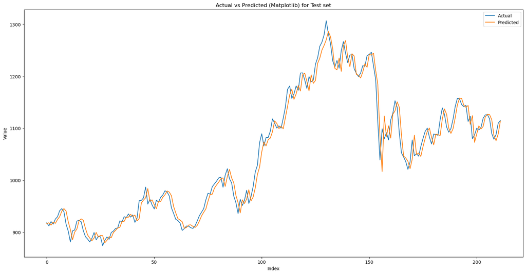

```python
plt.figure(figsize=(20, 10))
plt.plot(Y_test, label='Actual')
plt.plot(test_p, label='Predicted')
plt.xlabel('Index')
plt.ylabel('Value')
plt.title('Actual vs Predicted (Matplotlib) for Test set')
plt.legend()
plt.show()
```

```python
Y_test.shape
```

```
(212, 1)
```

```python
test_p.shape
```

```
(212, 1)
```

```python
Y_train=scale.inverse_transform(y_train)
```

```python
from sklearn.metrics import mean_squared_error, mean_absolute_percentage_error
mse_value = mean_squared_error(Y_train, train_p)

# Calculate MAPE
mape_value = mean_absolute_percentage_error(Y_train, train_p)

print("Mean Squared Error (MSE) Training set:", mse_value)
print("Mean Absolute Percentage Error (MAPE) Training Set:", mape_value, "%")
```

```
Mean Squared Error (MSE) Training set: 30.506941285205926
Mean Absolute Percentage Error (MAPE) Training Set: 0.004196611799956317 %
```

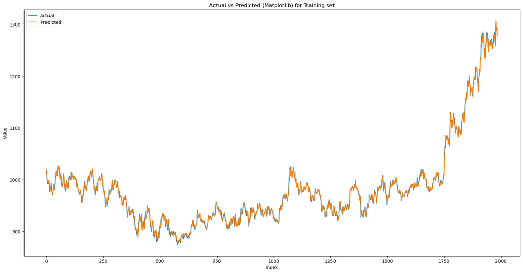

```python
plt.figure(figsize=(20, 10))
plt.plot(Y_train, label='Actual')
plt.plot(train_p, label='Predicted')
plt.xlabel('Index')
plt.ylabel('Value')
plt.title('Actual vs Predicted (Matplotlib) for Training set')
plt.legend()
plt.show()
```

```python
def calculate_mape(y_true, y_pred):
    mape = np.mean(np.abs((y_true - y_pred) / y_true)) * 100
    return mape
```

```python
mape_value = calculate_mape(Y_test, test_p)
```

```python
mape_value
```

```
1.3185434424432534
```

```python
print("Mean Absolute Percentage Error (MAPE):", mape_value, "%")
```

```
Mean Absolute Percentage Error (MAPE): 1.3185434424432534 %
```

# Stock Trading

```python
len(Y_test)
```

```
212
```

```python
len(test_p)
```

```
212
```

```python
ma=[np.mean(x) for x in x_test]
ma=scale.inverse_transform(np.array(ma).reshape(-1,1))
```

```python
len(ma)
```

```
212
```

```python
ma=ma.reshape(len(ma))
```

```python
Y_test=Y_test.reshape(len(ma))
test_p=test_p.reshape(len(ma))
```

```python
ma
```

```
array([ 901.60369873,  903.84743042,  905.72463379,  909.41465454,
        912.38153076,  915.32364502,  919.37028809,  922.83742676,
        924.90780029,  926.1708252 ,  926.44819946,  924.84836426,
        921.74280396,  919.9696106 ,  918.85517578,  918.4638855 ,
        917.78531494,  915.66045532,  911.42559814,  906.63599854,
        903.80285034,  901.71761475,  902.42589722,  902.09899902,
        900.19702759,  897.30444336,  894.12954102,  889.53806152,
        887.67075806,  887.62122803,  887.56179199,  889.38451538,
        890.78128052,  891.55890503,  893.85216675,  896.79923096,
        899.66209106,  905.22436523,  909.59295654,  914.02098389,
        918.29051514,  921.66849365,  923.34262085,  925.32384033,
        930.57407227,  934.50184326,  939.12304077,  944.81409912,
        947.41445313,  950.23273926,  952.57057495,  953.72463989,
        957.99417114,  961.07496948,  961.73372803,  962.78872681,
        964.16567383,  963.20477905,  964.75508423,  963.115625  ,
        961.50588379,  959.5147583 ,  955.5869873 ,  951.58988037,
        945.20539551,  938.73671265,  931.95598755,  925.39815063,
        919.305896  ,  915.33850098,  912.96104126,  912.63413696,
        913.57521973,  915.64559326,  919.8210144 ,  925.31889648,
        931.61422119,  937.78076782,  945.67592773,  954.23480225,
        962.81348267,  971.09993896,  978.49979248,  983.29434204,
        989.71845093,  995.72155151,  998.51011963, 1000.66965332,
        998.86674805,  995.23616333,  988.9953186 ,  984.85952148,
        979.41611938,  976.96436157,  974.0767334 ,  967.39506836,
        963.93288574,  963.20478516,  967.83588257,  975.06237793,
        988.67336426, 1001.28878174, 1012.74023438, 1024.73157349,
       1034.8803772 , 1048.78358765, 1063.75170898, 1075.95602417,
       1084.40097656, 1091.96428223, 1094.7677002 , 1097.74448242,
       1105.19387207, 1114.47093506, 1124.35721436, 1130.64758301,
       1135.43222656, 1142.59433594, 1149.85054932, 1160.00925293,
       1170.63850098, 1178.00368652, 1181.59959717, 1184.03648682,
       1184.87355957, 1188.38032227, 1194.12091064, 1199.52963867,
       1207.97459717, 1213.89844971, 1221.18438721, 1232.5565918 ,
       1243.1065918 , 1249.43164062, 1253.47828369, 1255.99443359,
       1256.69281006, 1254.69178467, 1253.89433594, 1254.00330811,
       1250.47178955, 1242.41812744, 1238.28728027, 1236.17728271,
       1234.61706543, 1233.42833252, 1230.33763428, 1229.39654541,
       1226.48911133, 1221.73417969, 1221.29335938, 1222.88328857,
       1223.42316895, 1221.29831543, 1219.237854  , 1209.83696289,
       1193.79898682, 1183.09050293, 1169.02384033, 1156.29450684,
       1140.08812256, 1127.48756104, 1115.77855225, 1109.05230713,
       1103.72281494, 1101.64748535, 1103.01452637, 1097.59588623,
       1093.20748291, 1086.14442749, 1081.89470825, 1078.05609741,
       1069.85880737, 1059.70010376, 1050.28435669, 1047.66914673,
       1050.40818481, 1055.30180054, 1061.73580933, 1067.94197998,
       1071.41901855, 1072.5730835 , 1076.62962646, 1080.15618896,
       1087.20438232, 1094.64387207, 1099.30964355, 1100.18137207,
       1099.40374756, 1101.01844482, 1105.79318848, 1111.06323242,
       1118.05198975, 1125.05560303, 1127.9333252 , 1128.16115723,
       1129.91948242, 1130.98438721, 1134.05032959, 1132.11864014,
       1129.08242187, 1124.90699463, 1118.81968994, 1113.33666992,
       1110.706604  , 1109.13154297, 1107.31378174, 1107.78928223,
       1104.46082764, 1104.35185547, 1104.43110352, 1105.39199219])
```

```python
principal = 100000
num_holdings = 0
short_hold = 0
threshold = 1
values = []
values.append(100000)
hold = []

for i in range(len(Y_test)):
    if test_p[i] > ma[i] * threshold:
        if short_hold > 0:
            # Cover a short position and take profit
            short_hold -= 1
            principal += Y_test[i]
        else:
            # Buy the stock
            num_holdings += 1
            principal -= Y_test[i]
    elif test_p[i] < ma[i] / threshold and num_holdings > 0:
        # Sell a long position and take profit
        num_holdings -= 1
        principal += Y_test[i]
    elif test_p[i] < ma[i] / threshold and short_hold == 0:
        # Short sell the stock if no long position is held
        short_hold += 1
        principal += Y_test[i]

    values.append(principal)
    hold.append(num_holdings)

principal += short_hold * Y_test[-1]
values[-1] = principal
```

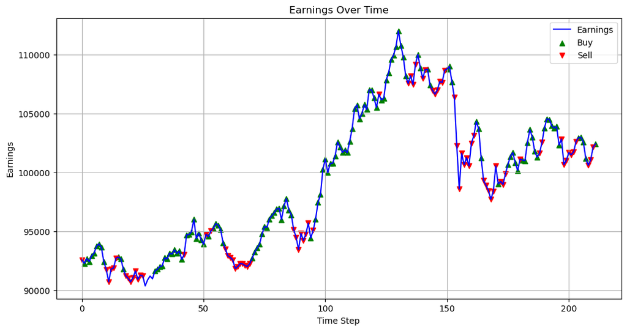

```python
# Calculate earnings at each time step
earnings = []
for i in range(len(values)-1):
    earnings.append(principal + (num_holdings * Y_test[i]))

# Ensure that time_steps and earnings have the same length
time_steps = list(range(len(Y_test)))

# Plot your earnings over time
plt.figure(figsize=(12, 6))
plt.plot(time_steps, earnings, label='Earnings', color='blue')
plt.xlabel('Time Step')
plt.ylabel('Earnings')
plt.title('Earnings Over Time')
plt.grid(True)

# Mark buy and sell points on the plot
buy_points = [i for i in range(len(hold)) if hold[i] > hold[i - 1]]
sell_points = [i for i in range(len(hold)) if hold[i] < hold[i - 1]]
plt.scatter(buy_points, [earnings[i] for i in buy_points], marker='^', color='green', label='Buy')
plt.scatter(sell_points, [earnings[i] for i in sell_points], marker='v', color='red', label='Sell')

plt.legend()
plt.show()
```

```python
#Calculating Return
# Assuming you have a list of daily portfolio values generated by your LSTM model
portfolio_values =  earnings

# Calculate the ROI
initial_investment = portfolio_values[0]
final_portfolio_value = portfolio_values[-1]
roi = (final_portfolio_value - initial_investment) / initial_investment * 100

print(f"Initial Investment: {initial_investment:.2f}")
print(f"Final Portfolio Value: {final_portfolio_value:.2f}")
print(f"ROI: {roi:.2f}%")
```

```
Initial Investment: 92579.64
Final Portfolio Value: 102413.92
ROI: 10.62%
```